# Updating Current Evidence with Generated RCTs

Arthur M. Albuquerque

December 21, 2021

```r
# Ensures the package "pacman" is installed
if (!require("pacman")) install.packages("pacman")

pacman::p_load(tidyverse, # data wrangling + plotting
               gt, # to create tables
               brms, # to fit Bayesian models
               here, # reproducible file paths
               tidybayes,
               ggdist,
               PNWColors,
               flextable) # table

# Load data
d_logOR = readRDS(
  here("03_updated_analyses_who", "output", "data", "effect_sizes.Rds")
  )

# Load main model
m1 = readRDS(here("03_updated_analyses_who", "output", "fits", "m1.Rds"))
```

In this document, we will update our current evidence (as modeled in our main meta-regression model) with generated randomized clinical trials (RCTs) of different sample sizes comparing tocilizumab to control on patients on invasive mechanical ventilation.

We will use the estimated marginal posterior mean and standard error on this subgroup to create a prior distribution. Then, we will use normal conjugate analyses to update this prior with new data (likelihood), and form an updated posterior distribution.

# Prior

As described in previous documents, we fitted a Bayesian meta-regression model, from which we estimated marginal posterior distributions on different subgroups.

Here, the subgroup of interest is the invasive mechanical ventilation:

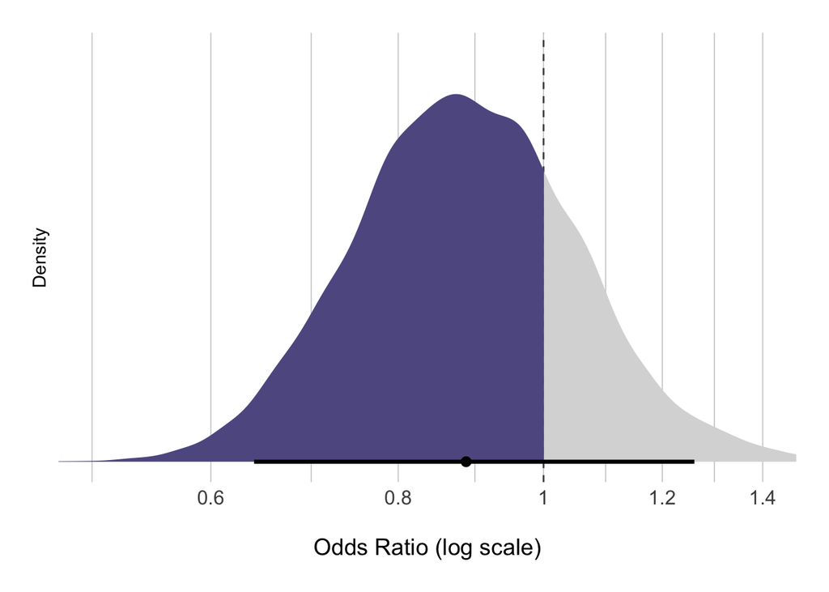

Marginal posterior distribution of the invasive mechanical ventilation subgroup. The interval bar depicts the mean and 95% quantile interval.

```r
m1 %>%
  tidy_draws() %>%

  # Plot!
  ggplot(aes(
    x = b_oxygenIMV,
    # https://github.com/mjskay/ggdist/issues/71
    fill_ramp = stat(x < log(1)))
  ) +
  geom_vline(xintercept = log(c(0.5, 0.7, 0.9, 1.1, 1.3)),
             color = "gray80", size = 0.3) +

  geom_vline(xintercept = log(1), linetype = 2, color = "gray30") +

  # https://mjskay.github.io/ggdist/articles/slabinterval.html
  stat_halfeye(point_interval = mean_qi,
               .width = 0.95,
               fill = "#605A91") +
  scale_fill_ramp_discrete(from = "gray85", range = c(0,1)) +

  labs(
    x = "\nOdds Ratio (log scale)",
    y = "Density"
  ) +
  scale_x_continuous(breaks = log(seq(from = 0.4, to = 1.4, 0.2)),
                     labels = seq(from = 0.4, to = 1.4, 0.2)) +
  coord_cartesian(xlim = log(c(0.5, 1.4))) +
  theme(
    strip.background = element_rect(fill = "#E4E6E7"),
    strip.text.x = element_text(size = 12),
    axis.ticks.x = element_blank(),
    axis.ticks.y = element_blank(),
    axis.text.x = element_text(size = 12),
    axis.title.x = element_text(size = 14),
    axis.text.y = element_blank(),
    panel.background = element_blank(),
    panel.grid.major.x = element_line(color = "gray80", size = 0.3),
    legend.position = 'none',
    plot.margin = margin(20, 20, 20, 20)
  )
```

In the linear scale, the mean of this marginal posterior distribution is 0.89. Because we will use normal conjugate analysis, it is of greater interest to evaluate this distribution on the log scale, which is approximately normally distributed. In this case, the mean is -0.12 and the standard error is 0.17.

# Likelihood

We will create six different RCTs and update the prior distribution mentioned above six separate times.

Assuming the prior is normally distributed

$$N(\theta,\sigma^2)$$

and so is the data (likelihood).

$$N(\hat{\theta},\hat{\sigma}^2)$$

The mean and variance of the posterior distributions can be estimated by the following formulas:

- Mean

$$\frac{\frac{\theta}{\sigma^2} + \frac{\hat\theta}{\hat\sigma^2}}{\frac{1}{\sigma^2}+\frac{1}{\hat\sigma^2}}$$

- Variance

$$\frac{1}{\frac{1}{\sigma^2}+\frac{1}{\hat\sigma^2}}$$

In summary, we are able to update a normally distributed prior distribution (shown in the Figure above) with normally distributed data to generate a normally distributed posterior distribution.

As mentioned before, we will create six different RCTs to separately generate six different posterior distributions (from the same prior distribution). Therefore, we now have to decide the mean and standard deviation of the likelihood.

```r
### Overall mean odds ratio in WHO's meta-analysis on tocilizumab in patients
# using corticosteroids:

# The mean odds ratio in patients using corticosteroids (toci vs control)
# was 0.77 (page 14 in Supplement 2 doi:10.1001/jama.2021.11330)

mean_OR_WHO = 0.77
```

All RCTs will have a mean of -0.26 (log scale). This value is the equal to 0.77 in the linear scale, which was chosen based on WHO’s meta-analysis (page 14 in Supplement 2). This is the mean odds ratio of tocilizumab vs. control in patients using corticosteroids (overall results).

Here are our assumptions to calculate the standard deviation of each RCTs:

```r
control_risk = 0.43

# Now, we need to calculate the risk in the tocilizumab arm based on the odds ratio
# and control risk mentioned above

# Reference for formula: Box 1 in https://doi.org/10.1016/j.jclinepi.2020.08.019

toci_risk = (control_risk*mean_OR_WHO)/(control_risk*(mean_OR_WHO - 1) + 1)
```

1. We assume equal allocation in both treatment arms (tocilizumab and control).
2. Adapting from the suggestions in the [GRADE guidelines](http://dx.doi.org/10.1016/j.jclinepi.2012.01.012), we found a striking discrepancy between the control mortality risk in this data (52%) in comparison to another [previously published meta-analysis](https://jamanetwork.com/journals/jama/fullarticle/2770279?utm_campaign=articlePDF&utm_medium=articlePDFlink&utm_source=articlePDF&utm_content=jama.2020.17023) (34% in patients on IVM and using corticosteroids). Thus, we have decided to use 43% (arithmetic mean between 34 and 52) as our reference risk in the IVM subgroup..
3. The mortality risk in the tocilizumab was calculated using the following formula (Box 1 in [Doi et al., 2020](https://doi.org/10.1016/j.jclinepi.2020.08.019)):

$$R_{T} = \frac{R_{C} O R}{R_{C}\left(O R-1\right)+1}$$

where $R_{T}$ is the mortality risk in the tocilizumab group, $R_{C}$ is the mortality risk in the control group and $OR$ is the odds ratio mentioned above. Thus, the tocilizumab risk is equal to 0.37.

Thus, we are simulating RCTs with mean OR equal to 0.77, control risk mortality of 0.43, and tocilizumab risk of 0.37.

Based on these values, we can estimate the standard deviation ($SD$) with the following [formula](https://doi.org/10.1016/j.jclinepi.2008.07.006):

$$SD=\sqrt{\frac{1}{a+\frac{1}{2}}+\frac{1}{b+\frac{1}{2}}+\frac{1}{c+\frac{1}{2}}+\frac{1}{d+\frac{1}{2}}}$$

where $a$, $b$, $c$ and $d$ are number of events and follow this 2x2 table:

```r
tribble(

  ~"Event", ~"Tocilizumab", ~"Control",

  "Death", "a", "c",
  "No death", "b", "d"
) %>%
  flextable() %>%
  autofit()
```

| Event | Tocilizumab | Control |
| --- | --- | --- |
| Death | a | c |
| No death | b | d |

As similarly shown in the supplementary material of [Higgins and Spiegelhalter, 2002](https://academic.oup.com/ije/article/31/1/96/655931?login=true), we can estimate these values as:

- $a = R_{T}SS_{T}$
- $b = SS_{T} - R_{T}SS_{T}$
- $c = R_{C}SS_{C}$
- $d = SS_{C} - R_{C}SS_{C}$

where $SS_{T}$ and $SS_{C}$ are the sample sizes in the tocilizumab and control arms, respectively. As mentioned above, we assume equal allocation in both treatment arms, thus $SS_{T} = SS_{C}$.

```r
# Function to calculate the standard deviation of odds ratio from simulated RCT ,
# based on risk and total sample size in each treatment arm
# Here we assume both arms have the same number of total patients (total_arm)

# Adapted from:
# Appendix in https://doi.org/10.1093/ije/31.1.96
# +
# Appendix in https://doi.org/10.1016/j.jclinepi.2008.07.006

SD_fun = function(risk_toci, # Risk in tocilizumab arm
                  risk_control, # Risk in control arm
                  total_arm){ # Total sample size in each arm

# Tocilizumab
a = risk_toci*total_arm                     # Deaths
b = total_arm - risk_toci*total_arm         # No deaths
# Control
c = risk_control*total_arm                  # Deaths
d = total_arm - risk_control*total_arm      # No deaths

# Standard deviation =
sqrt(1/(a + 1/2) + 1/(b + 1/2) + 1/(c + 1/2) + 1/(d + 1/2))

                  }
```

```r
# Lastly, we should apply the function above to calculate the standard deviation
# of multiple simulated RCTs will the same risk_toci and risk_control, but
# different amounts of patients

df =
  tibble(risk_toci = toci_risk,
         risk_control = control_risk,
         total_arm = c(100, 250, 500, 750, 1000, 2000)) %>%
  mutate(SD = SD_fun(risk_toci, risk_control, total_arm))
```

Finally, we can estimate the $SD$ (log scale) based on the 6 different sample sizes mentioned above:

```r
df %>%
  summarise("Sample size in each treatment arm" = total_arm,
            "Total sample size" = 2*total_arm,
            " SD" = round(SD,2)) %>%
  flextable() %>%
  autofit()
```

| Sample size in each treatment arm | Total sample size | SD |
| --- | --- | --- |
| 100 | 200 | 0.29 |
| 250 | 500 | 0.18 |
| 500 | 1,000 | 0.13 |
| 750 | 1,500 | 0.11 |
| 1,000 | 2,000 | 0.09 |
| 2,000 | 4,000 | 0.06 |

# Posterior

We will now apply the normal conjugate analysis to update our prior belief (current evidence) with new RCTs.

```r
## Functions

# Spiegelhalter DJ, Abrams KR, Myles JP. Bayesian Approaches to Clinical Trials
# and Health Care Evaluation. Wiley; 2004.

post.normal.mean <- function(prior.mean, prior.var, data.mean, data.var)
{
  post.mean.numerator <- prior.mean/prior.var + data.mean/data.var
  post.mean.denominator <- 1/prior.var + 1/data.var
  post.mean <-  post.mean.numerator/post.mean.denominator
  return(post.mean)
}

post.normal.sd <- function(prior.var, data.var)
{
  post.var <- (1/(1/prior.var + 1/data.var))
  post.sd <- sqrt(post.var)
  return(post.sd)
}
```

```r
# Prior and Data

prior_data = tibble(

  prior_mean = fixef(m1)["oxygenIMV", "Estimate"],
  prior_sd = fixef(m1)["oxygenIMV", "Est.Error"],

  data_sample_size = 2*df$total_arm,
  data_mean = log(mean_OR_WHO),
  data_sd = df$SD
)

# Generate the posterior

prior_data_posterior =

  prior_data %>%
    mutate(post_mean =
             post.normal.mean(prior.mean = prior_mean, prior.var = prior_sd^2,
                              data.mean = data_mean, data.var = data_sd^2),

           post_sd = post.normal.sd(prior.var = prior_sd^2,
                                    data.var = data_sd^2))

# Save it
save(prior_data_posterior,
     file = here("03_updated_analyses_who", "output", "data",
                 "prior_data_posterior.rds"))
```

Lastly, we will perform these analyses with RCTs centered at no effect (OR = 1).

```r
# Prior and Data

prior_data = tibble(

  prior_mean = fixef(m1)["oxygenIMV", "Estimate"],
  prior_sd = fixef(m1)["oxygenIMV", "Est.Error"],

  data_sample_size = 2*df$total_arm,
  data_mean = log(1),
  data_sd = df$SD
)

# Generate the posterior

prior_data_posterior_skeptical =

  prior_data %>%
    mutate(post_mean =
             post.normal.mean(prior.mean = prior_mean, prior.var = prior_sd^2,
                              data.mean = data_mean, data.var = data_sd^2),

           post_sd = post.normal.sd(prior.var = prior_sd^2,
                                    data.var = data_sd^2))

# Save it
save(prior_data_posterior_skeptical,
     file = here("03_updated_analyses_who", "output", "data",
                 "prior_data_posterior_skeptical.rds"))
```